# Lista 2

Geometria Analítica 2021.1

Prof. Fernando Náufel

(v. 03/09/2021)

# Instruções

- Fique à vontade para consultar os coleguinhas e para usar programas como o Geogebra, mas somente soluções *analíticas* serão aceitas — nada de responder no olhômetro.
- Documente da forma mais clara possível todos os passos da resolução de cada questão.
- Entregue (via Moodle) sua resolução escrita no formato que você preferir: manuscrito escaneado ou fotografado, documento gerado via $\LaTeX$ etc. O importante é que a resolução esteja legível. Se você for fotografar sua resolução, use um aplicativo como [Clear Scan](https://play.google.com/store/apps/details?id=com.indymobileapp.document.scanner) para gerar um resultado melhor.
- Além da resolução por escrito, entregue também (via Moodle) um arquivo contendo um vídeo de no máximo 5 minutos onde você explica em detalhes a resolução de uma parte da sua questão.
- Bom trabalho.

# Questão única: construindo uma casa

Considere $n$ o seu número na lista de alunos da sua turma.

Veja o seu número nesta lista.

Você vai achar equações para o chão, as paredes e o telhado de uma casa no $\mathbb{R}^3$.

Em todos os seus cálculos e respostas, use frações e radicais.

Não use valores numéricos com vírgulas decimais em momento algum.

## Chão

- O chão da casa está no plano que contém o ponto $A = (1, -1, 0)$ e que é normal ao vetor $\vec v = \left(1, 1, n\right)$.
- Observe que o chão da casa não é horizontal — i.e., não é o plano $XY$.
- Ache a equação cartesiana deste plano.
- O chão da casa é um quadrado contido neste plano.
- O ponto $A$ é um dos cantos da casa — i.e., onde o chão e duas das paredes se encontram.
- O outro canto da casa é o ponto $C = \left(-1, 1, 0\right)$.
- O segmento $\overline{AC}$ é a diagonal do chão.
- Ache a área do chão da casa.
- Ache as coordenadas dos outros dois cantos da sala (pontos $B$ e $D$).

  Dica: o que você sabe sobre o ponto $B$ é o que você precisa para descobrir as suas coordenadas.
  1. $B$ pertence ao plano do chão.
  2. A distância de $A$ a $B$ é igual ao lado do quadrado.
  3. A distância de $C$ a $B$ é igual ao lado do quadrado.

  Como, a partir destas informações, você vai chegar a uma equação do segundo grau, você também vai ganhar, de presente, as coordenadas de $D$, que, afinal, é um ponto que também satisfaz as três condições acima!

  Para padronizar as respostas, tome como ponto $B$ o ponto com $x$ e $y$ positivos, e como ponto $D$ o ponto com $x$ e $y$ negativos.
- Ache as equações paramétricas das quatro retas que são as interseções das paredes com o chão — i.e., as retas que contêm os rodapés da casa.
- Neste momento, a situação é a da figura abaixo:

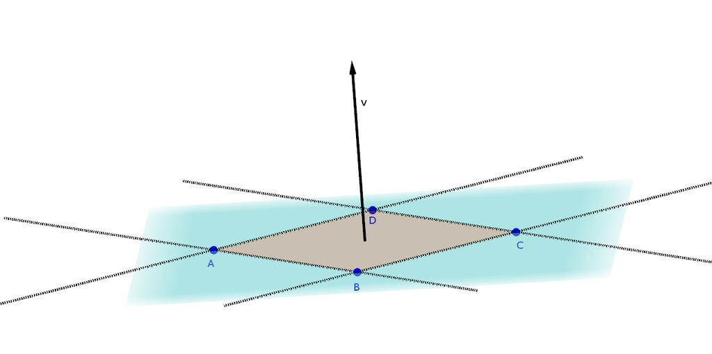

## Paredes

- As quatro paredes, como de costume, estão contidas em planos perpendiculares ao chão.
- Ache as equações paramétricas destes quatro planos.
- A situação agora é esta (limitando os planos das paredes a valores específicos dos parâmetros):

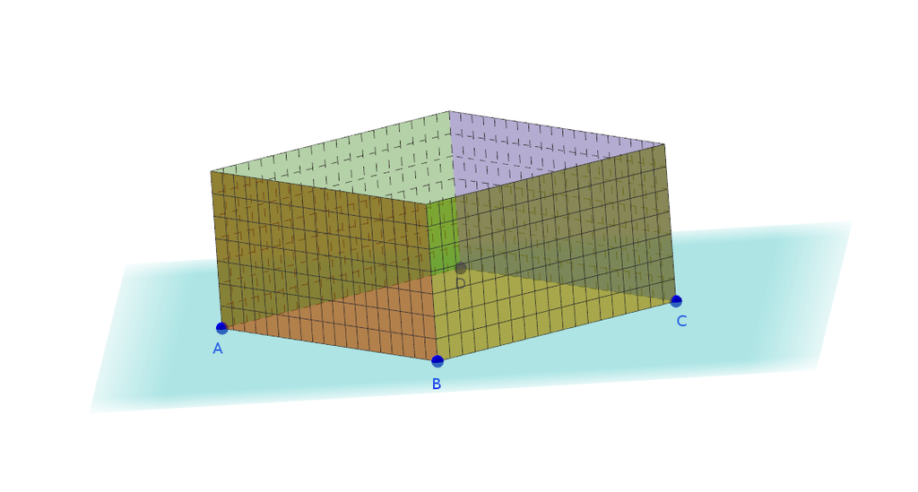

- Para gerar cada parede no Geogebra, usei [o comando *Surface*](https://wiki.geogebra.org/en/Surface_Command), que recebe três equações paramétricas (de $x$, de $y$, e de $z$), os nomes dos dois parâmetros, e os valores mínimos e máximos para cada parâmetro.
- Você vai ganhar um ponto extra se mostrar, em um vídeo separado (de até 5 minutos), como fazer isso com o comando *Surface* no Geogebra.
- Ou seja, escreva chamadas do comando *Surface* que desenhem as paredes sem ultrapassar os limites dos cantos da casa e com exatamente $1$ unidade de altura.

## Teto

- O vetor $\vec v = \left(1, 1, n\right)$ aponta do chão para o teto.
- Como de costume, o teto é paralelo ao chão.
- O teto fica a $1$ unidade de distância do chão.
- Ache as coordenadas dos pontos $A'$, $B'$, $C'$ e $D'$, que são os cantos do teto diretamente acima de $A$, $B$, $C$ e $D$, respectivamente.

  Dica: o vetor $\overrightarrow{AA'}$ é unitário e tem a mesma direção de um vetor cujas coordenadas você já conhece.
- Ache a equação cartesiana do plano que contém o teto.

## Telhado

- O telhado é como na figura:

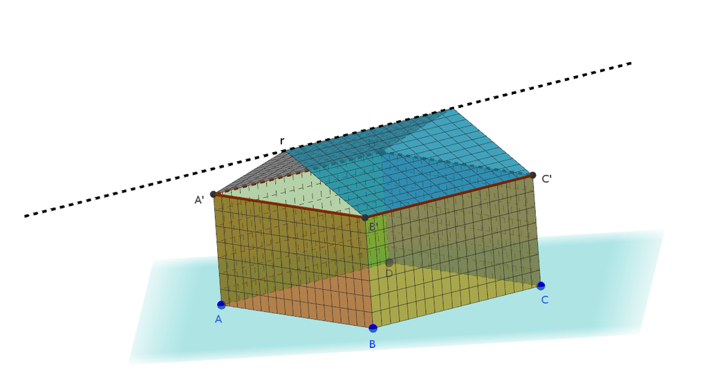

- A distância entre o teto e o ponto mais alto do telhado, medida a partir do ponto médio do segmento $\overline{A'B'}$, é de $\frac 1 2$ unidade.
- Ache as equações cartesianas dos dois planos que contêm os dois lados do telhado.
- Ache a equação da reta $r$, indicada na figura acima, que contém a interseção entre os dois lados do telhado.

  Dica: use o produto vetorial.

# Números dos alunos, por matrícula

| matrícula | n |
| --- | --- |
| 119060020 | 47 |
| 119060022 | 42 |
| 119060029 | 41 |
| 119060034 | 29 |
| 120060012 | 2 |
| 120060016 | 14 |
| 120060018 | 1 |
| 120060031 | 21 |
| 120060032 | 11 |
| 120060035 | 7 |
| 121060001 | 33 |
| 121060002 | 9 |
| 121060003 | 15 |
| 121060004 | 20 |
| 121060005 | 12 |
| 121060006 | 8 |
| 121060007 | 24 |
| 121060008 | 25 |
| 121060009 | 5 |
| 121060010 | 45 |
| 121060011 | 35 |
| 121060012 | 32 |
| 121060013 | 19 |
| 121060014 | 30 |
| 121060015 | 13 |
| 121060016 | 43 |
| 121060017 | 27 |
| 121060019 | 38 |
| 121060020 | 4 |
| 121060021 | 23 |
| 121060022 | 40 |
| 121060023 | 26 |
| 121060024 | 31 |
| 121060025 | 3 |
| 121060026 | 36 |
| 121060028 | 37 |
| 121060029 | 44 |
| 218060072 | 34 |
| 218060076 | 46 |
| 219060057 | 6 |
| 219060078 | 39 |
| 220060041 | 28 |
| 220060042 | 22 |
| 220060056 | 17 |
| 220060070 | 10 |
| 318060036 | 18 |
| 319060003 | 16 |